# HJA FTICR-MS 2016 vs 2025

August 31, 2026

# Dataset and paired-site identification

```r
data_file <- "Results/HJA_2016_HJW_2025-Processed_Data_Final.csv"
mol_file <- "Results/HJA_2016_HJW_2025-Processed_Mol_Final.csv"
compound_file <- "Results/HJA_2016_HJW_2025_Compound_Class_Summary.csv"
elemental_file <- "Results/HJA_2016_HJW_2025_Elemental_Composition_Summary.csv"
property_file <- "Results/HJA_2016_HJW_2025_MolInfo_Summary.csv"
coordinates_2016_file <- "WHONDRS_HJA_2016_Sample_Data/WHONDRS_HJA_2016_Coordinates.csv"
metadata_2025_file <- "v2_WHONDRS_HJW_Sample_Data/WHONDRS_HJW_Field_Metadata.csv"

feature_data <- read.csv(data_file, check.names = FALSE)
molecular_data <- read.csv(mol_file, check.names = FALSE)

if (names(feature_data)[1] != "Calibrated m/z" || names(molecular_data)[1] != "Calibrated m/z") {
  stop("The first column in both final Data and Mol files must be 'Calibrated m/z'.")
}
if (anyDuplicated(feature_data[[1]]) > 0 || anyDuplicated(molecular_data[[1]]) > 0) {
  stop("Duplicate calibrated-mass feature rows were detected.")
}
if (!identical(feature_data[[1]], molecular_data[[1]])) {
  stop("The final Data and Mol feature rows are not identical and in the same order.")
}

sample_names <- names(feature_data)[-1]
if (anyDuplicated(sample_names) > 0) {
  stop("Duplicate sample names were detected in the final presence/absence matrix.")
}

presence_absence <- as.matrix(feature_data[, sample_names, drop = FALSE])
storage.mode(presence_absence) <- "numeric"
observed_values <- sort(unique(as.vector(presence_absence)))
unexpected_values <- setdiff(observed_values[!is.na(observed_values)], c(0, 1))
if (length(unexpected_values) > 0) {
  stop(
    "The final molecular matrix contains non-binary values: ",
    paste(unexpected_values, collapse = ", ")
  )
}

sample_inventory <- tibble(sample = sample_names) %>%
  mutate(
    year = str_extract(sample, "(2016|2025)$"),
    site_name = str_remove(sample, "^HJA_") %>% str_remove("_(2016|2025)$")
  )
if (any(is.na(sample_inventory$year))) {
  stop("At least one sample name does not end in 2016 or 2025.")
}
if (anyDuplicated(sample_inventory %>% select(site_name, year)) > 0) {
  stop("Duplicate site-year sample names were detected after parsing sample names.")
}

coordinates_2016 <- read_csv(coordinates_2016_file, show_col_types = FALSE) %>%
  transmute(
    site_name_2016 = as.character(Site_ID),
    latitude_2016 = Latitude,
    longitude_2016 = Longitude
  )
metadata_2025 <- read_csv(metadata_2025_file, show_col_types = FALSE) %>%
  transmute(
    site_name_2025 = as.character(Site_ID),
    latitude_2025 = Latitude,
    longitude_2025 = Longitude
  )
if (anyDuplicated(coordinates_2016$site_name_2016) > 0 || anyDuplicated(metadata_2025$site_name_2025) > 0) {
  stop("Duplicate site IDs were found in one of the coordinate files.")
}
```

```r
samples_2016 <- sample_inventory %>%
  filter(year == "2016") %>%
  transmute(sample_2016 = sample, site_name_2016 = site_name)
samples_2025 <- sample_inventory %>%
  filter(year == "2025") %>%
  transmute(sample_2025 = sample, site_name_2025 = site_name)

exact_pairs <- samples_2016 %>%
  inner_join(samples_2025, by = c("site_name_2016" = "site_name_2025")) %>%
  mutate(
    site_name_2025 = site_name_2016,
    match_type = "exact_name"
  )

renamed_candidates <- tribble(
  ~site_name_2016, ~site_name_2025,
  "CC-1-15m", "CC-1",
  "CC-2-55m", "CC-2",
  "CC-3-100m", "CC-3",
  "CC-4-250m", "CC-4",
  "KC-1-275m", "KC-1",
  "KC-2-360m", "KC-2",
  "KC-3-400m", "KC-3",
  "KerryCreek2", "KC-4",
  "WS1_250m", "WS1-4",
  "WS3-1_30m", "WS3-1"
)

coordinate_threshold_m <- 100
renamed_candidate_diagnostics <- renamed_candidates %>%
  left_join(samples_2016, by = "site_name_2016") %>%
  left_join(samples_2025, by = "site_name_2025") %>%
  left_join(coordinates_2016, by = "site_name_2016") %>%
  left_join(metadata_2025, by = "site_name_2025") %>%
  mutate(
    latitude_2016_rad = latitude_2016 * pi / 180,
    latitude_2025_rad = latitude_2025 * pi / 180,
    latitude_difference = (latitude_2025 - latitude_2016) * pi / 180,
    longitude_difference = (longitude_2025 - longitude_2016) * pi / 180,
    haversine_a = sin(latitude_difference / 2)^2 +
      cos(latitude_2016_rad) * cos(latitude_2025_rad) * sin(longitude_difference / 2)^2,
    distance_m = 6371000 * 2 * atan2(sqrt(haversine_a), sqrt(1 - haversine_a)),
    decision = case_when(
      is.na(sample_2016) | is.na(sample_2025) ~ "excluded_missing_sample",
      is.na(distance_m) ~ "excluded_missing_coordinates",
      distance_m <= coordinate_threshold_m ~ "confirmed_coordinate_verified",
      TRUE ~ "excluded_distance_over_100_m"
    )
  ) %>%
  select(
    site_name_2016, site_name_2025, sample_2016, sample_2025,
    latitude_2016, longitude_2016, latitude_2025, longitude_2025,
    distance_m, decision
  )

write_csv(
  renamed_candidate_diagnostics,
  "Analysis_Results/HJA_2016_2025_renamed_site_candidate_diagnostics.csv"
)

coordinate_verified_pairs <- renamed_candidate_diagnostics %>%
  filter(decision == "confirmed_coordinate_verified") %>%
  transmute(
    sample_2016,
    sample_2025,
    site_name_2016,
    site_name_2025,
    match_type = "coordinate_verified"
  )

site_pairing <- bind_rows(exact_pairs, coordinate_verified_pairs) %>%
  left_join(coordinates_2016, by = "site_name_2016") %>%
  left_join(metadata_2025, by = "site_name_2025") %>%
  mutate(
    latitude_2016_rad = latitude_2016 * pi / 180,
    latitude_2025_rad = latitude_2025 * pi / 180,
    latitude_difference = (latitude_2025 - latitude_2016) * pi / 180,
    longitude_difference = (longitude_2025 - longitude_2016) * pi / 180,
    haversine_a = sin(latitude_difference / 2)^2 +
      cos(latitude_2016_rad) * cos(latitude_2025_rad) * sin(longitude_difference / 2)^2,
    distance_m = 6371000 * 2 * atan2(sqrt(haversine_a), sqrt(1 - haversine_a)),
    site_pair_id = paste0("PAIR_", stringr::str_pad(row_number(), width = 3, pad = "0")),
    .before = 1
  ) %>%
  select(
    site_pair_id, sample_2016, sample_2025, site_name_2016, site_name_2025,
    latitude_2016, longitude_2016, latitude_2025, longitude_2025,
    distance_m, match_type
  ) %>%
  arrange(site_name_2016)

if (anyDuplicated(site_pairing$site_pair_id) > 0 ||
    anyDuplicated(site_pairing$sample_2016) > 0 ||
    anyDuplicated(site_pairing$sample_2025) > 0) {
  stop("Duplicate site pairs or reused samples were detected in the confirmed pairing table.")
}
if (any(is.na(site_pairing$sample_2016)) || any(is.na(site_pairing$sample_2025))) {
  stop("A confirmed pair is missing a sample name.")
}
if (any(!site_pairing$sample_2016 %in% sample_names) ||
    any(!site_pairing$sample_2025 %in% sample_names)) {
  stop("A confirmed paired sample is missing from the final presence/absence matrix.")
}
if (any(is.na(site_pairing$latitude_2016)) || any(is.na(site_pairing$latitude_2025))) {
  stop("Coordinates are missing for at least one confirmed pair.")
}

write_csv(site_pairing, "Analysis_Results/HJA_2016_2025_site_pairing.csv")

unpaired_2016 <- samples_2016 %>%
  filter(!sample_2016 %in% site_pairing$sample_2016)
unpaired_2025 <- samples_2025 %>%
  filter(!sample_2025 %in% site_pairing$sample_2025)
write_csv(unpaired_2016, "Analysis_Results/HJA_2016_2025_unpaired_2016_sites.csv")
write_csv(unpaired_2025, "Analysis_Results/HJA_2016_2025_unpaired_2025_sites.csv")

pairing_summary <- tibble(
  measure = c(
    "Total 2016 samples", "Total 2025 samples", "Exact-name pairs",
    "Coordinate-verified renamed pairs", "Total confirmed pairs",
    "Unpaired 2016 sites", "Unpaired 2025 sites"
  ),
  count = c(
    nrow(samples_2016), nrow(samples_2025),
    sum(site_pairing$match_type == "exact_name"),
    sum(site_pairing$match_type == "coordinate_verified"),
    nrow(site_pairing), nrow(unpaired_2016), nrow(unpaired_2025)
  )
)
write_csv(pairing_summary, "Analysis_Results/HJA_2016_2025_pairing_summary.csv")

site_display_order <- site_pairing %>%
  arrange(site_name_2025) %>%
  pull(site_name_2025)

site_order <- site_pairing %>%
  arrange(site_name_2025) %>%
  pull(site_pair_id)

sample_metadata <- site_pairing %>%
  transmute(
    site_pair_id,
    site_display_name = site_name_2025,
    sample_2016,
    sample_2025
  ) %>%
  pivot_longer(
    cols = c(sample_2016, sample_2025),
    names_to = "year_source",
    values_to = "sample"
  ) %>%
  mutate(
    year = factor(if_else(year_source == "sample_2016", "2016", "2025"), levels = year_levels),
    site_pair_id = factor(site_pair_id, levels = site_order),
    site_display_name = factor(site_display_name, levels = site_display_order)
  ) %>%
  select(site_pair_id, site_display_name, sample, year)
```

There were **60 2016 samples**, **47 2025 samples**, and **44 confirmed paired sites**. Of these, 34 were exact-name matches and 10 were coordinate-verified renamed matches. 16 2016 sites and 3 2025 sites were excluded from paired analyses.

Paired-site accounting

| measure | count |
| --- | --- |
| Total 2016 samples | 60 |
| Total 2025 samples | 47 |
| Exact-name pairs | 34 |
| Coordinate-verified renamed pairs | 10 |
| Total confirmed pairs | 44 |
| Unpaired 2016 sites | 16 |
| Unpaired 2025 sites | 3 |

# 1. Molecular richness

Molecular richness is the number of molecular formulas detected in a sample.

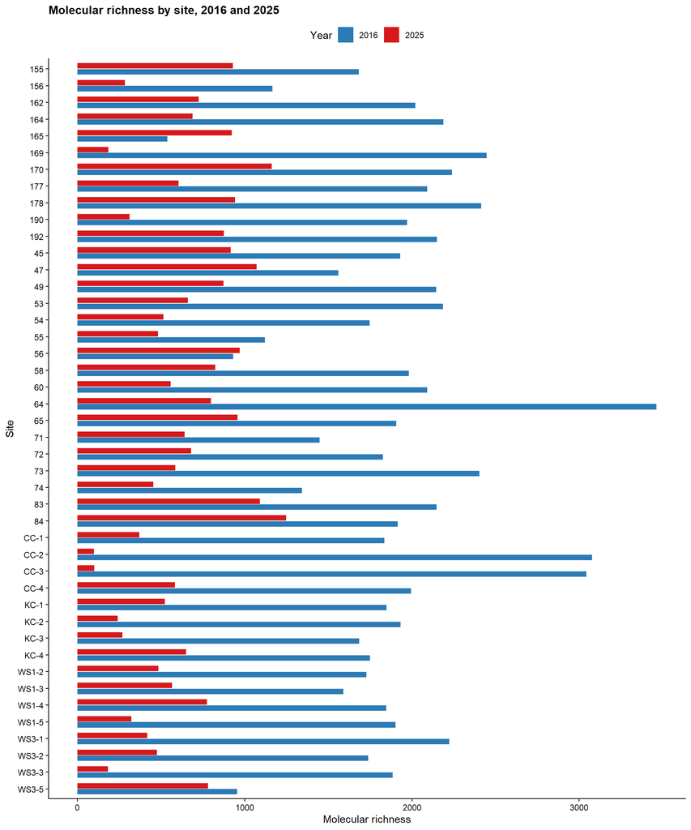

```r
paired_sample_names <- c(site_pairing$sample_2016, site_pairing$sample_2025)
paired_presence_absence <- presence_absence[, paired_sample_names, drop = FALSE]

if (any(colSums(paired_presence_absence, na.rm = TRUE) == 0)) {
  stop("At least one confirmed paired sample has zero detected molecular features.")
}

richness_long <- tibble(
  sample = colnames(paired_presence_absence),
  richness = colSums(paired_presence_absence, na.rm = TRUE)
) %>%
  left_join(sample_metadata, by = "sample")
if (any(is.na(richness_long$site_pair_id))) {
  stop("A richness sample was not found in the confirmed pairing table.")
}

richness_by_site <- richness_long %>%
  mutate(year = as.character(year)) %>%
  select(site_pair_id, year, richness) %>%
  pivot_wider(names_from = year, values_from = richness, names_prefix = "richness_") %>%
  mutate(richness_change = richness_2025 - richness_2016) %>%
  left_join(
    site_pairing %>%
      transmute(site_pair_id, site_name = site_name_2025, site_name_2016, site_name_2025),
    by = "site_pair_id"
  ) %>%
  select(
    site_pair_id, site_name, site_name_2016, site_name_2025,
    richness_2016, richness_2025, richness_change
  )
write_csv(richness_by_site, "Analysis_Results/HJA_2016_2025_richness_by_site.csv")

richness_test <- richness_by_site %>%
  transmute(
    value_2016 = richness_2016,
    value_2025 = richness_2025
  ) %>%
  paired_test_summary("Molecular richness")
write_csv(richness_test, "Analysis_Results/HJA_2016_2025_richness_statistics.csv")

figure_richness <- richness_long %>%
  mutate(site_display_name = factor(site_display_name, levels = rev(site_display_order))) %>%
  ggplot(aes(x = richness, y = site_display_name, fill = year)) +
  geom_col(position = position_dodge2(width = 0.8, preserve = "single"), width = 0.72) +
  scale_fill_manual(values = year_colors, drop = FALSE) +
  labs(
    x = "Molecular richness",
    y = "Site",
    fill = "Year",
    title = "Molecular richness by site, 2016 and 2025"
  ) +
  publication_theme
save_figure(figure_richness, "Figure_Richness_2016_2025", width = 10, height = 12)
```

Across 44 paired sites, mean richness was 1911.1 in 2016 and 631.6 in 2025; medians were 1910.5 and 623. The mean paired change was -1279.5 formulas and the median change was -1267.5. The test statistic was 4 (V), with p = 1.04e-08, and the rank_biserial effect size was -0.992.

# 2. Overall molecular composition

[figure not shown]

```r
community_matrix <- t(paired_presence_absence)
community_matrix[is.na(community_matrix)] <- 0

jaccard_distance <- vegdist(community_matrix, method = "jaccard", binary = TRUE)
set.seed(20162025)
nmds_result <- metaMDS(
  community_matrix,
  distance = "jaccard",
  binary = TRUE,
  k = 2,
  trymax = 500,
  autotransform = FALSE,
  trace = FALSE
)
if (!nmds_result$converged) {
  stop("NMDS did not converge after trymax = 500.")
}

nmds_scores <- as.data.frame(scores(nmds_result, display = "sites")) %>%
  rownames_to_column("sample") %>%
  left_join(sample_metadata, by = "sample") %>%
  arrange(site_pair_id, year)
if (any(is.na(nmds_scores$site_pair_id))) {
  stop("An NMDS sample was not found in the confirmed pairing table.")
}
write_csv(nmds_scores, "Analysis_Results/HJA_2016_2025_NMDS_scores.csv")

permanova_metadata <- sample_metadata %>%
  mutate(sample = factor(sample, levels = rownames(community_matrix))) %>%
  arrange(sample) %>%
  mutate(
    year = factor(year, levels = year_levels),
    site_pair_id = factor(site_pair_id)
  )
if (!identical(as.character(permanova_metadata$sample), rownames(community_matrix))) {
  stop("Community-matrix rows and PERMANOVA metadata are not aligned.")
}

permutation_count <- 9999
paired_permutations <- how(
  blocks = permanova_metadata$site_pair_id,
  within = Within(type = "free"),
  nperm = permutation_count
)
set.seed(20162025)
permanova_result <- adonis2(
  jaccard_distance ~ year,
  data = permanova_metadata,
  permutations = paired_permutations
)
permanova_table <- tibble(
  term = "Year",
  pseudo_F = permanova_result$F[1],
  R2 = permanova_result$R2[1],
  p_value = permanova_result$`Pr(>F)`[1],
  permutations = permutation_count,
  permutation_design = "Free swaps within paired-site blocks"
)
write_csv(permanova_table, "Analysis_Results/HJA_2016_2025_PERMANOVA.csv")

dispersion_result <- betadisper(jaccard_distance, group = permanova_metadata$year)
set.seed(20162025)
dispersion_permutation <- permutest(
  dispersion_result,
  permutations = paired_permutations
)
dispersion_anova <- anova(dispersion_result)
dispersion_table <- tibble(
  term = "Year",
  F = dispersion_anova$`F value`[1],
  p_value_permutation = dispersion_permutation$tab$`Pr(>F)`[1],
  p_value_parametric = dispersion_anova$`Pr(>F)`[1],
  permutations = permutation_count,
  permutation_design = "Free swaps within paired-site blocks"
)
write_csv(dispersion_table, "Analysis_Results/HJA_2016_2025_betadisper.csv")

figure_nmds <- ggplot(nmds_scores, aes(x = NMDS1, y = NMDS2)) +
 # geom_path(aes(group = site_pair_id), color = "black", linewidth = 0.3, alpha = 0.35) +
  geom_point(aes(color = year, shape = year), size = 2.5, alpha = 0.9) +
  scale_color_manual(values = year_colors, drop = FALSE) +
  scale_shape_manual(values = c("2016" = 16, "2025" = 17), drop = FALSE) +
  coord_equal() +
  labs(
    x = "NMDS axis 1",
    y = "NMDS axis 2",
    color = "Year",
    shape = "Year",
    title = "Jaccard NMDS of detected molecular features",
    subtitle = paste0("Paired sites connected; stress = ", round(nmds_result$stress, 3))
  ) +
  publication_theme
save_figure(figure_nmds, "Figure_NMDS_Jaccard_2016_2025", width = 8, height = 7)
```

The two-dimensional NMDS converged with stress = 0.123. Year explained 16.22% of Jaccard variation (PERMANOVA, pseudo-F = 16.645, p = 1e-04). The dispersion test gave F = 56.059 and permutation p = 1e-04. Because dispersion differs significantly by year, the PERMANOVA result may reflect both a shift in composition and a change in among-site variability and should be interpreted cautiously.

# 3. Compound-class composition

For each sample, each class count was divided by the total number of classified detected formulas. The plot therefore shows the **percent of detected molecular formulas** assigned to each compound class.

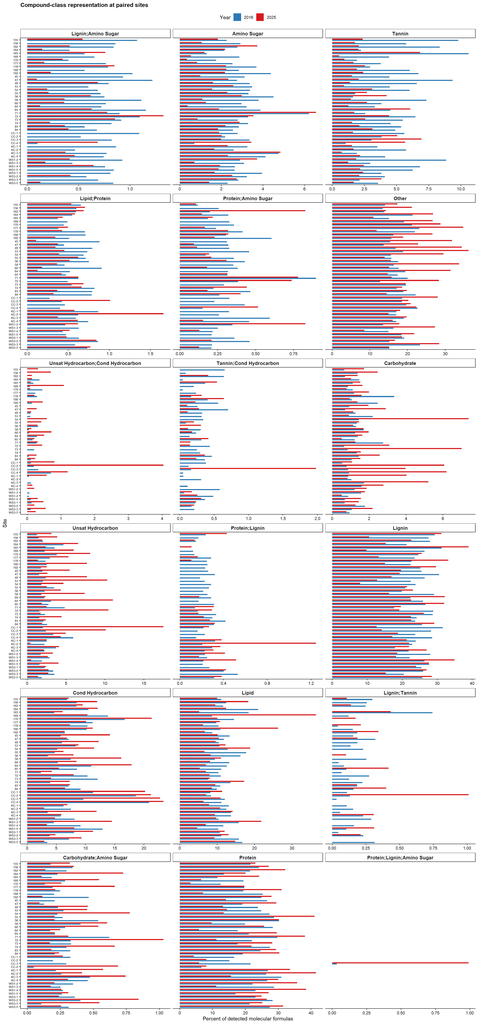

Compound-class paired tests. Means and changes are percentage points.

| class | n_pairs | mean_2016 | mean_2025 | mean_change | test | p_value | p_adjusted_BH |
| --- | --- | --- | --- | --- | --- | --- | --- |
| Lignin;Amino Sugar | 44 | 0.76 | 0.32 | -0.45 | Paired t-test | 0.00e+00 | 0.00e+00 |
| Amino Sugar | 44 | 3.08 | 2.09 | -0.98 | Paired t-test | 4.00e-07 | 3.50e-06 |
| Tannin | 44 | 4.83 | 2.52 | -2.31 | Paired t-test | 1.50e-06 | 9.00e-06 |
| Lipid;Protein | 44 | 0.60 | 0.41 | -0.19 | Paired Wilcoxon signed-rank test | 1.93e-04 | 8.66e-04 |
| Protein;Amino Sugar | 44 | 0.33 | 0.19 | -0.14 | Paired Wilcoxon signed-rank test | 6.14e-04 | 2.09e-03 |
| Other | 44 | 17.60 | 21.52 | 3.92 | Paired t-test | 6.96e-04 | 2.09e-03 |
| Unsat Hydrocarbon;Cond Hydrocarbon | 44 | 0.12 | 0.38 | 0.25 | Paired Wilcoxon signed-rank test | 1.01e-03 | 2.61e-03 |
| Tannin;Cond Hydrocarbon | 44 | 0.26 | 0.18 | -0.08 | Paired Wilcoxon signed-rank test | 1.93e-03 | 3.50e-03 |
| Carbohydrate | 44 | 1.26 | 2.22 | 0.96 | Paired Wilcoxon signed-rank test | 1.95e-03 | 3.50e-03 |
| Unsat Hydrocarbon | 44 | 2.55 | 4.50 | 1.96 | Paired Wilcoxon signed-rank test | 1.95e-03 | 3.50e-03 |
| Protein;Lignin | 44 | 0.24 | 0.16 | -0.08 | Paired Wilcoxon signed-rank test | 2.49e-03 | 4.07e-03 |
| Lignin | 44 | 25.11 | 21.76 | -3.35 | Paired t-test | 5.56e-03 | 8.34e-03 |
| Cond Hydrocarbon | 44 | 8.32 | 10.01 | 1.69 | Paired t-test | 1.76e-02 | 2.44e-02 |
| Lipid | 44 | 12.16 | 11.09 | -1.07 | Paired Wilcoxon signed-rank test | 2.32e-02 | 2.98e-02 |
| Lignin;Tannin | 44 | 0.15 | 0.10 | -0.05 | Paired Wilcoxon signed-rank test | 2.65e-02 | 3.18e-02 |
| Carbohydrate;Amino Sugar | 44 | 0.28 | 0.36 | 0.07 | Paired t-test | 7.73e-02 | 8.70e-02 |
| Protein | 44 | 22.34 | 22.17 | -0.18 | Paired Wilcoxon signed-rank test | 9.21e-01 | 9.75e-01 |
| Protein;Lignin;Amino Sugar | 44 | 0.00 | 0.02 | 0.02 | Paired Wilcoxon signed-rank test | 1.00e+00 | 1.00e+00 |

```r
compound_summary <- read.csv(compound_file, check.names = FALSE)
names(compound_summary)[1] <- "sample"
if (anyDuplicated(compound_summary$sample) > 0) {
  stop("Duplicate sample names were detected in the compound-class summary.")
}
if (any(!paired_sample_names %in% compound_summary$sample)) {
  stop("At least one confirmed paired sample is missing from the compound-class summary.")
}
compound_summary_only <- setdiff(compound_summary$sample, paired_sample_names)
message(length(compound_summary_only), " unpaired compound-summary samples were checked and excluded.")

compound_paired <- compound_summary %>%
  filter(sample %in% paired_sample_names)
compound_totals <- rowSums(compound_paired[, -1, drop = FALSE], na.rm = TRUE)
if (any(compound_totals <= 0)) {
  stop("A paired sample has a zero compound-class total.")
}

compound_long <- compound_paired %>%
  mutate(classified_total = compound_totals) %>%
  pivot_longer(
    cols = -c(sample, classified_total),
    names_to = "class",
    values_to = "formula_count"
  ) %>%
  mutate(relative_abundance = formula_count / classified_total) %>%
  left_join(sample_metadata, by = "sample")
if (any(is.na(compound_long$relative_abundance)) || any(is.na(compound_long$site_pair_id))) {
  stop("Unexpected NA values were introduced in compound-class proportions or pairing metadata.")
}

compound_wide <- compound_long %>%
  mutate(year = as.character(year)) %>%
  select(class, site_pair_id, year, relative_abundance) %>%
  pivot_wider(names_from = year, values_from = relative_abundance, names_prefix = "value_")

compound_statistics <- compound_wide %>%
  group_split(class) %>%
  map_dfr(~ paired_test_summary(.x, unique(.x$class))) %>%
  rename(class = variable) %>%
  mutate(p_adjusted_BH = p.adjust(p_value, method = "BH")) %>%
  select(
    class, n_pairs, mean_2016, mean_2025, median_2016, median_2025,
    mean_change, median_change, shapiro_p_difference, selection_reason,
    test, statistic_name, statistic, p_value, p_adjusted_BH,
    effect_size_name, effect_size
  ) %>%
  arrange(p_adjusted_BH, p_value)
write_csv(
  compound_statistics,
  "Analysis_Results/HJA_2016_2025_compound_class_statistics.csv"
)

compound_plot_data <- compound_long %>%
  mutate(
    percent = 100 * relative_abundance,
    site_display_name = factor(site_display_name, levels = rev(site_display_order)),
    year = factor(year, levels = year_levels),
    class = factor(class, levels = compound_statistics$class)
  )

figure_compound <- ggplot(compound_plot_data, aes(x = percent, y = site_display_name, fill = year)) +
  geom_col(position = position_dodge2(width = 0.8, preserve = "single"), width = 0.72) +
  facet_wrap(~ class, ncol = 3, scales = "free_x") +
  scale_fill_manual(values = year_colors, drop = FALSE) +
  labs(
    x = "Percent of detected molecular formulas",
    y = "Site",
    fill = "Year",
    title = "Compound-class representation at paired sites"
  ) +
  publication_theme +
  theme(axis.text.y = element_text(size = 6.5))
compound_rows <- ceiling(length(unique(compound_plot_data$class)) / 3)
compound_height <- max(12, compound_rows * 5)
save_figure(
  figure_compound,
  "Figure_Compound_Classes_2016_2025",
  width = 14,
  height = compound_height
)
```

15 of 18 compound classes had FDR-adjusted p < 0.05. The strongest FDR-supported changes were observed for Lignin;Amino Sugar, Amino Sugar, Tannin. These results describe proportional representation among detected and classified formulas and do not measure peak intensity.

# 4. Elemental composition

Elemental-class counts were converted to the percent of classified detected formulas in each sample. All elemental classes present in the summary file were retained.

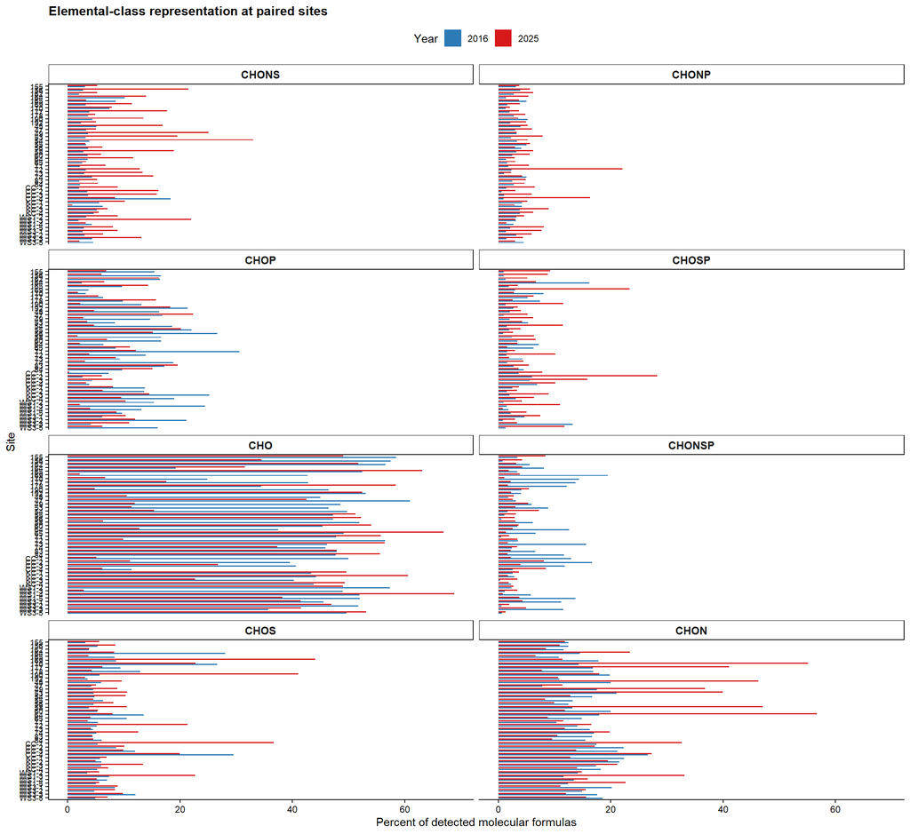

Elemental-composition paired tests. Means and changes are percentage points.

| class | n_pairs | mean_2016 | mean_2025 | mean_change | test | p_value | p_adjusted_BH |
| --- | --- | --- | --- | --- | --- | --- | --- |
| CHONS | 44 | 4.15 | 10.50 | 6.36 | Paired t-test | 1.80e-06 | 7.50e-06 |
| CHONP | 44 | 2.75 | 5.40 | 2.65 | Paired Wilcoxon signed-rank test | 1.90e-06 | 7.50e-06 |
| CHOP | 44 | 13.37 | 8.44 | -4.94 | Paired t-test | 4.94e-05 | 1.32e-04 |
| CHOSP | 44 | 3.55 | 6.77 | 3.22 | Paired Wilcoxon signed-rank test | 9.38e-04 | 1.88e-03 |
| CHO | 44 | 45.81 | 35.07 | -10.74 | Paired Wilcoxon signed-rank test | 5.99e-03 | 9.20e-03 |
| CHONSP | 44 | 6.35 | 3.31 | -3.04 | Paired Wilcoxon signed-rank test | 6.90e-03 | 9.20e-03 |
| CHOS | 44 | 7.84 | 10.66 | 2.82 | Paired Wilcoxon signed-rank test | 1.37e-01 | 1.56e-01 |
| CHON | 44 | 16.19 | 19.86 | 3.67 | Paired Wilcoxon signed-rank test | 8.56e-01 | 8.56e-01 |

```r
elemental_summary <- read.csv(elemental_file, check.names = FALSE)
names(elemental_summary)[1] <- "sample"
if (anyDuplicated(elemental_summary$sample) > 0) {
  stop("Duplicate sample names were detected in the elemental-composition summary.")
}
if (any(!paired_sample_names %in% elemental_summary$sample)) {
  stop("At least one confirmed paired sample is missing from the elemental-composition summary.")
}
elemental_summary_only <- setdiff(elemental_summary$sample, paired_sample_names)
message(length(elemental_summary_only), " unpaired elemental-summary samples were checked and excluded.")

elemental_paired <- elemental_summary %>%
  filter(sample %in% paired_sample_names)
elemental_totals <- rowSums(elemental_paired[, -1, drop = FALSE], na.rm = TRUE)
if (any(elemental_totals <= 0)) {
  stop("A paired sample has a zero elemental-composition total.")
}

elemental_long <- elemental_paired %>%
  mutate(classified_total = elemental_totals) %>%
  pivot_longer(
    cols = -c(sample, classified_total),
    names_to = "class",
    values_to = "formula_count"
  ) %>%
  mutate(relative_abundance = formula_count / classified_total) %>%
  left_join(sample_metadata, by = "sample")
if (any(is.na(elemental_long$relative_abundance)) || any(is.na(elemental_long$site_pair_id))) {
  stop("Unexpected NA values were introduced in elemental proportions or pairing metadata.")
}

elemental_wide <- elemental_long %>%
  mutate(year = as.character(year)) %>%
  select(class, site_pair_id, year, relative_abundance) %>%
  pivot_wider(names_from = year, values_from = relative_abundance, names_prefix = "value_")

elemental_statistics <- elemental_wide %>%
  group_split(class) %>%
  map_dfr(~ paired_test_summary(.x, unique(.x$class))) %>%
  rename(class = variable) %>%
  mutate(p_adjusted_BH = p.adjust(p_value, method = "BH")) %>%
  select(
    class, n_pairs, mean_2016, mean_2025, median_2016, median_2025,
    mean_change, median_change, shapiro_p_difference, selection_reason,
    test, statistic_name, statistic, p_value, p_adjusted_BH,
    effect_size_name, effect_size
  ) %>%
  arrange(p_adjusted_BH, p_value)
write_csv(
  elemental_statistics,
  "Analysis_Results/HJA_2016_2025_elemental_composition_statistics.csv"
)

elemental_plot_data <- elemental_long %>%
  mutate(
    percent = 100 * relative_abundance,
    site_display_name = factor(site_display_name, levels = rev(site_display_order)),
    year = factor(year, levels = year_levels),
    class = factor(class, levels = elemental_statistics$class)
  )

figure_elemental <- ggplot(elemental_plot_data, aes(x = percent, y = site_display_name, fill = year)) +
  geom_col(position = position_dodge2(width = 0.8, preserve = "single"), width = 0.72) +
  facet_wrap(~ class, ncol = 2) +
  scale_fill_manual(values = year_colors, drop = FALSE) +
  labs(
    x = "Percent of detected molecular formulas",
    y = "Site",
    fill = "Year",
    title = "Elemental-class representation at paired sites"
  ) +
  publication_theme +
  theme(axis.text.y = element_text(size = 7))
elemental_rows <- ceiling(length(unique(elemental_plot_data$class)) / 2)
elemental_height <- max(10, elemental_rows * 5.5)
save_figure(
  figure_elemental,
  "Figure_Elemental_Composition_2016_2025",
  width = 12,
  height = elemental_height
)
```

6 of 8 elemental classes had FDR-adjusted p < 0.05. The strongest FDR-supported changes were observed for CHONS, CHONP, CHOP.

# 5. Molecular properties

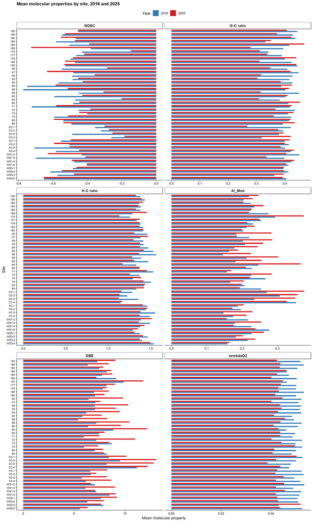

Paired tests of selected mean molecular properties.

| property | n_pairs | mean_2016 | mean_2025 | mean_change | test | p_value | p_adjusted_BH |
| --- | --- | --- | --- | --- | --- | --- | --- |
| DBE | 44 | 7.34200 | 8.9070 | 1.565000 | Paired t-test | 0.00e+00 | 0.00e+00 |
| lambdaO2 | 44 | 0.05032 | 0.0434 | -0.006924 | Paired Wilcoxon signed-rank test | 1.00e-07 | 2.00e-07 |
| H:C ratio | 44 | 1.39900 | 1.3510 | -0.047760 | Paired t-test | 1.09e-03 | 2.18e-03 |
| AI_Mod | 44 | 0.21740 | 0.2421 | 0.024670 | Paired t-test | 2.27e-03 | 3.41e-03 |
| NOSC | 44 | -0.51640 | -0.4559 | 0.060500 | Paired t-test | 3.71e-03 | 4.46e-03 |
| O:C ratio | 44 | 0.40680 | 0.3845 | -0.022320 | Paired t-test | 9.80e-03 | 9.80e-03 |

```r
property_summary <- read.csv(property_file, check.names = FALSE)
names(property_summary)[1] <- "sample"
if (anyDuplicated(property_summary$sample) > 0) {
  stop("Duplicate sample names were detected in the molecular-property summary.")
}
if (any(!paired_sample_names %in% property_summary$sample)) {
  stop("At least one confirmed paired sample is missing from the molecular-property summary.")
}
property_summary_only <- setdiff(property_summary$sample, paired_sample_names)
message(length(property_summary_only), " unpaired molecular-property samples were checked and excluded.")

property_mapping <- tribble(
  ~property, ~source_column, ~plausible_min, ~plausible_max,
  "NOSC", "NOSC.mean", -4, 4,
  "O:C ratio", "OtoC.mean", 0, 2,
  "H:C ratio", "HtoC.mean", 0, 3,
  "AI_Mod", "AI_Mod.mean", -1, 1,
  "DBE", "DBE.mean", 0, 100,
  "lambdaO2", "lambdaO2_7.mean", -1, 1
)
missing_property_columns <- setdiff(property_mapping$source_column, names(property_summary))
if (length(missing_property_columns) > 0) {
  stop(
    "Requested molecular-property mean columns are missing: ",
    paste(missing_property_columns, collapse = ", ")
  )
}

property_source_diagnostics <- property_summary %>%
  filter(sample %in% paired_sample_names) %>%
  select(sample, all_of(property_mapping$source_column)) %>%
  pivot_longer(-sample, names_to = "source_column", values_to = "summary_value") %>%
  left_join(property_mapping, by = "source_column") %>%
  group_by(property, source_column, plausible_min, plausible_max) %>%
  summarise(
    minimum_existing_mean = min(summary_value, na.rm = TRUE),
    maximum_existing_mean = max(summary_value, na.rm = TRUE),
    nonfinite_mean_count = sum(!is.finite(summary_value)),
    outside_plausible_range_count = sum(
      summary_value < plausible_min | summary_value > plausible_max,
      na.rm = TRUE
    ),
    .groups = "drop"
  ) %>%
  mutate(
    recalculation_required = nonfinite_mean_count > 0 | outside_plausible_range_count > 0,
    decision = if_else(
      recalculation_required,
      "Recalculate from final Mol and binary Data files",
      "Existing summary passed range check"
    )
  )
write_csv(
  property_source_diagnostics,
  "Analysis_Results/HJA_2016_2025_molecular_property_source_diagnostics.csv"
)

if (any(property_source_diagnostics$recalculation_required)) {
  stop(
    "The molecular-property summary contains invalid values. Regenerate it from the corrected staged CoreMS files."
  )
}

property_long <- property_summary %>%
  filter(sample %in% paired_sample_names) %>%
  select(sample, all_of(property_mapping$source_column)) %>%
  pivot_longer(
    -sample,
    names_to = "source_column",
    values_to = "value"
  ) %>%
  left_join(
    property_mapping %>% select(property, source_column),
    by = "source_column"
  ) %>%
  select(sample, property, value) %>%
  left_join(sample_metadata, by = "sample")
if (any(is.na(property_long$value)) || any(is.na(property_long$site_pair_id))) {
  stop("Unexpected NA values were found in molecular-property means or pairing metadata.")
}
write_csv(
  property_long %>% select(site_pair_id, sample, year, property, value),
  "Analysis_Results/HJA_2016_2025_molecular_properties_by_sample.csv"
)

property_wide <- property_long %>%
  mutate(year = as.character(year)) %>%
  select(property, site_pair_id, year, value) %>%
  pivot_wider(names_from = year, values_from = value, names_prefix = "value_")

property_statistics <- property_wide %>%
  group_split(property) %>%
  map_dfr(~ paired_test_summary(.x, unique(.x$property))) %>%
  rename(property = variable) %>%
  mutate(
    p_adjusted_BH = p.adjust(p_value, method = "BH"),
    calculation_source = "Corrected upstream Results molecular-property summary"
  ) %>%
  select(
    property, n_pairs, mean_2016, mean_2025, median_2016, median_2025,
    mean_change, median_change, shapiro_p_difference, selection_reason,
    test, statistic_name, statistic, p_value, p_adjusted_BH,
    effect_size_name, effect_size, calculation_source
  ) %>%
  arrange(p_adjusted_BH, p_value)
write_csv(
  property_statistics,
  "Analysis_Results/HJA_2016_2025_molecular_property_statistics.csv"
)

figure_properties <- property_long %>%
  mutate(
    year = factor(year, levels = year_levels),
    property = factor(property, levels = property_mapping$property),
    site_display_name = factor(site_display_name, levels = rev(site_display_order))
  ) %>%
  ggplot(aes(x = value, y = site_display_name, fill = year)) +
  geom_col(position = position_dodge2(width = 0.8, preserve = "single"), width = 0.72) +
  facet_wrap(~ property, scales = "free_x", ncol = 2) +
  scale_fill_manual(values = year_colors, drop = FALSE) +
  labs(
    x = "Mean molecular property",
    y = "Site",
    fill = "Year",
    title = "Mean molecular properties by site, 2016 and 2025"
  ) +
  publication_theme +
  theme(axis.text.y = element_text(size = 7))
save_figure(
  figure_properties,
  "Figure_Molecular_Properties_2016_2025",
  width = 12,
  height = 20
)
```

6 of the 6 selected molecular properties had FDR-adjusted p < 0.05. The strongest FDR-supported shifts were observed for DBE, lambdaO2, H:C ratio. The grouped bars show the two years directly for every site.